# ML_Assignment

# Practical Machine Learning Assignment

## Executive summary

In this project, the data from accelerometers on the belt, forearm, arm, and dumbell of 6 participants are used. The participants were asked to perform barbell lifts correctly and incorrectly in 5 different ways. The goal of this project is to predict the manner in which they did the exercise. This is the “classe” variable in the training set. The data for this project come from this source: http://groupware.les.inf.puc-rio.br/har. Three different (applying different training methods) models were developed, and the model using random forest was found to be most accurate (lowest out-of-sample error). The final prediction using this model on the 20 test cases were all correct.

## Preliminary elimination of features for modeling

The test data set pm-testing.csv was analyzed first. The analysis showed that out of the 160 features (variables) in the test data set, for 100 features no data are available, so these need to be eliminated from the training data set before training any model. Also out of the remaining 60 features for which data were available, judging from purpose of the model the features “X”, “user_name”, “raw_timestamp_part_1”, “raw_timestamp_part_2”, “new_window” & “num_window” were also eliminated from the predictor list in the model. Based on the elimination strategy, the training and test data sets were pruned to keep only the relevant features (in all 54) for training and final prediction for submission of the assignment.

```r
testing <- read.csv("./pml-testing.csv")   # Test data for prediction submission
   # checking for NA variables or variables with no data
slct <- which(sapply(testing, function(x)all(!is.na(x))))
   # creating the test data only with populated variables
test_sel <- testing[,slct]
   # removing variables deemed not relevant as predictors
test_sel <- test_sel[,c(-1,-2,-3,-4,-6,-7)]

training <- read.csv("./pml-training.csv") # Training data for creating predictive model
train_sel <- training[,slct]  # selecting only the populated variables
train_sel <- train_sel[,c(-1,-2,-3,-4,-6,-7)]  # removing variables deemed not relevant as predictors
```

## Creating Data set for cross-validation

Simple cross-validation was implemented in this model by first dividing the training data into a 70:30 split, where 30% of the training data is separated into a validation set, to check the out-of-sample error for the final model. Also a cursory check (see plot in Appendix) of the data suggests that it contains time series data for events to be classified. So the data split was made based on the variable cvtd_timestamp to make sure that we capature the full cycle of data for a particular event (manner of dumbell exercise) on a particular day, both for training and validation data sets. The remaining 70% of the training set was again split into training and test sets using a 70:30 ratio to be used for model building.

```r
library(lattice)
library(ggplot2)
library(AppliedPredictiveModeling)
library(caret)
set.seed(5493)
inBuild <- createDataPartition(y=train_sel$cvtd_timestamp,
                               p=0.7, list=FALSE)
validation <- train_sel[-inBuild,]   # for out-of-sample error check
buildData  <- train_sel[inBuild,]    # data to train and test the model
inTrain <- createDataPartition(y=buildData$cvtd_timestamp,
                               p=0.7, list=FALSE)
trainClasse <- buildData[inTrain,]   # Data to train the model
testClasse  <- buildData[-inTrain,]  # Data for testing the model
```

## Developing three different models

```r
library(e1071)
library(rpart)
library(randomForest)
library(MASS)

set.seed(3939)
  # creating the three models
mod_rpart <- train(classe ~ ., method="rpart", data=trainClasse[,-1],
              tuneLength=50)
mod_rf    <- train(classe ~ ., method="rf", data=trainClasse[,-1],
              trControl = trainControl(method="cv"), number=3)
mod_lda   <- train(classe ~ ., method="lda", data=trainClasse[,-1])

dim(trainClasse[,-1])
mod_rpart
pred_rf    <- predict(mod_rf, testClasse)
pred_rpart <- predict(mod_rpart, testClasse)
pred_lda   <- predict(mod_lda, testClasse)

   # comparing the accuracy of the three models
confusionMatrix(pred_rf, testClasse$classe)
confusionMatrix(pred_rpart, testClasse$classe)
confusionMatrix(pred_lda, testClasse$classe)
```

## Checking the out-of-sample error rate

Next the three different models were checked against the validation data set to evaluate the out-of-sample error rate. Here also the random forest model proved to be the most accurate with an accuarcy of 98.8%. Since the models were trained with about 50% of the original training set, the expectation was that out-of-sample errors (on the validation data set) will be almost similar or worse than the test data set. The results show that they were almost similar. This may be attributed to the appropriate filtering of the features without any valid data and also eliminating the ones adjudged irrelevant predictors based on common sense (does not help explaining the outcome), which resulted in limiting effects of overfitting (picking up the noise).

```r
confusionMatrix(predict(mod_rf, validation), validation$classe)
confusionMatrix(predict(mod_lda, validation), validation$classe)
confusionMatrix(predict(mod_rpart, validation), validation$classe)
```

## Selecting the model to be used for final prediction (20 test cases)

Based on the above findings the random forest model was chosen as the model to be used for final prediction using the 20 test data points in pml_testing.csv file. All the 20 points were correctly predicted by this model.

```r
   # Final prediction with the test data (pml-testing.csv) for
   # submission
predTest <- predict(mod_rf, test_sel)
```

The predicted results were then appropriately formatted in separate files for submission using the following function.

```r
pml_write_files = function(x){
  n = length(x)
  for(i in 1:n){
    filename = paste0("problem_id_",i,".txt")
    write.table(x[i],file=filename,quote=FALSE,row.names=FALSE,col.names=FALSE)
  }
}
pml_write_files(predTest)
```

## Appendix

### Sample plot of time series data (roll_arm feature)

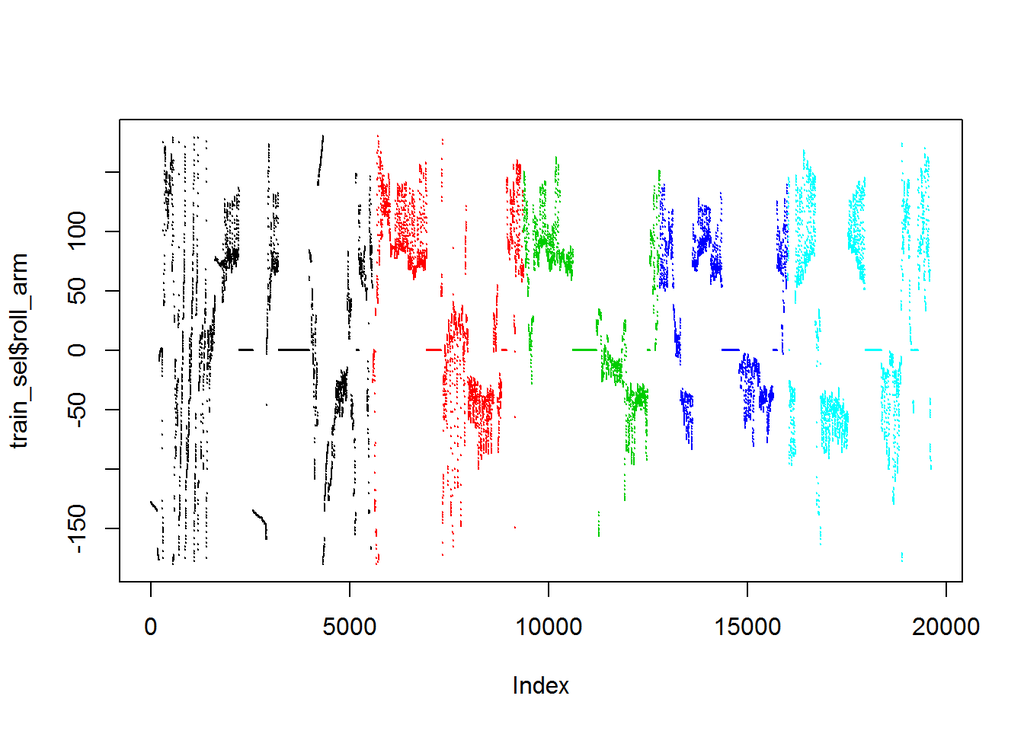

```r
plot(train_sel$roll_arm, cex=0.1, col=train_sel$classe)
```

### Accuracy of the models based on the sample test data (21% of original training data)

```r
confusionMatrix(pred_rf, testClasse$classe)
```

```
## Confusion Matrix and Statistics
##
##           Reference
## Prediction    A    B    C    D    E
##          A 1178    7    0    0    0
##          B    1  753   13    0    0
##          C    1    4  719   28    7
##          D    0    1    1  635    0
##          E    0    0    0    0  765
##
## Overall Statistics
##
##                Accuracy : 0.9847
##                  95% CI : (0.9804, 0.9882)
##     No Information Rate : 0.2869
##     P-Value [Acc > NIR] : < 2.2e-16
##
##                   Kappa : 0.9806
##  Mcnemar's Test P-Value : NA
##
## Statistics by Class:
##
##                      Class: A Class: B Class: C Class: D Class: E
## Sensitivity            0.9983   0.9843   0.9809   0.9578   0.9909
## Specificity            0.9976   0.9958   0.9882   0.9994   1.0000
## Pos Pred Value         0.9941   0.9817   0.9473   0.9969   1.0000
## Neg Pred Value         0.9993   0.9964   0.9958   0.9919   0.9979
## Prevalence             0.2869   0.1860   0.1782   0.1612   0.1877
## Detection Rate         0.2864   0.1831   0.1748   0.1544   0.1860
## Detection Prevalence   0.2881   0.1865   0.1845   0.1549   0.1860
## Balanced Accuracy      0.9980   0.9901   0.9845   0.9786   0.9955
```

```r
confusionMatrix(pred_rpart, testClasse$classe)
```

```
## Confusion Matrix and Statistics
##
##           Reference
## Prediction    A    B    C    D    E
##          A 1113   51    7   12    2
##          B   32  656   55   18   22
##          C   15   27  647   25    9
##          D    7   21   19  594   22
##          E   13   10    5   14  717
##
## Overall Statistics
##
##                Accuracy : 0.9062
##                  95% CI : (0.8968, 0.9149)
##     No Information Rate : 0.2869
##     P-Value [Acc > NIR] : < 2.2e-16
##
##                   Kappa : 0.8812
##  Mcnemar's Test P-Value : 0.000142
##
## Statistics by Class:
##
##                      Class: A Class: B Class: C Class: D Class: E
## Sensitivity            0.9432   0.8575   0.8827   0.8959   0.9288
## Specificity            0.9755   0.9621   0.9775   0.9800   0.9874
## Pos Pred Value         0.9392   0.8378   0.8949   0.8959   0.9447
## Neg Pred Value         0.9771   0.9673   0.9746   0.9800   0.9836
## Prevalence             0.2869   0.1860   0.1782   0.1612   0.1877
## Detection Rate         0.2706   0.1595   0.1573   0.1444   0.1743
## Detection Prevalence   0.2881   0.1904   0.1758   0.1612   0.1845
## Balanced Accuracy      0.9593   0.9098   0.9301   0.9380   0.9581
```

```r
confusionMatrix(pred_lda, testClasse$classe)
```

```
## Confusion Matrix and Statistics
##
##           Reference
## Prediction   A   B   C   D   E
##          A 958 104  62  51  36
##          B  38 495  81  32 129
##          C  89  87 471  81  93
##          D  90  34  96 477  96
##          E   5  45  23  22 418
##
## Overall Statistics
##
##                Accuracy : 0.6854
##                  95% CI : (0.6709, 0.6996)
##     No Information Rate : 0.2869
##     P-Value [Acc > NIR] : < 2.2e-16
##
##                   Kappa : 0.602
##  Mcnemar's Test P-Value : < 2.2e-16
##
## Statistics by Class:
##
##                      Class: A Class: B Class: C Class: D Class: E
## Sensitivity            0.8119   0.6471   0.6426   0.7195   0.5415
## Specificity            0.9137   0.9164   0.8964   0.9084   0.9716
## Pos Pred Value         0.7911   0.6387   0.5737   0.6015   0.8148
## Neg Pred Value         0.9235   0.9191   0.9204   0.9440   0.9017
## Prevalence             0.2869   0.1860   0.1782   0.1612   0.1877
## Detection Rate         0.2329   0.1204   0.1145   0.1160   0.1016
## Detection Prevalence   0.2944   0.1884   0.1996   0.1928   0.1247
## Balanced Accuracy      0.8628   0.7817   0.7695   0.8139   0.7565
```

### Accuracy of the models based on the validation (out-of-sample) test data (30% of original training data)

```r
confusionMatrix(predict(mod_rf, validation), validation$classe)
```

```
## Confusion Matrix and Statistics
##
##           Reference
## Prediction    A    B    C    D    E
##          A 1661    4    0    0    0
##          B    4 1142   18    0    0
##          C    1   10 1014   19    3
##          D    0    2    5  940    3
##          E    0    0    0    0 1053
##
## Overall Statistics
##
##                Accuracy : 0.9883
##                  95% CI : (0.9852, 0.9909)
##     No Information Rate : 0.2834
##     P-Value [Acc > NIR] : < 2.2e-16
##
##                   Kappa : 0.9852
##  Mcnemar's Test P-Value : NA
##
## Statistics by Class:
##
##                      Class: A Class: B Class: C Class: D Class: E
## Sensitivity            0.9970   0.9862   0.9778   0.9802   0.9943
## Specificity            0.9991   0.9953   0.9932   0.9980   1.0000
## Pos Pred Value         0.9976   0.9811   0.9685   0.9895   1.0000
## Neg Pred Value         0.9988   0.9966   0.9952   0.9961   0.9988
## Prevalence             0.2834   0.1970   0.1764   0.1631   0.1801
## Detection Rate         0.2825   0.1943   0.1725   0.1599   0.1791
## Detection Prevalence   0.2832   0.1980   0.1781   0.1616   0.1791
## Balanced Accuracy      0.9980   0.9908   0.9855   0.9891   0.9972
```

```r
confusionMatrix(predict(mod_lda, validation), validation$classe)
```

```
## Confusion Matrix and Statistics
##
##           Reference
## Prediction    A    B    C    D    E
##          A 1382  159  101   60   35
##          B   45  757  118   40  201
##          C  117  135  706  101   83
##          D  115   53   94  718  107
##          E    7   54   18   40  633
##
## Overall Statistics
##
##                Accuracy : 0.7137
##                  95% CI : (0.702, 0.7253)
##     No Information Rate : 0.2834
##     P-Value [Acc > NIR] : < 2.2e-16
##
##                   Kappa : 0.6376
##  Mcnemar's Test P-Value : < 2.2e-16
##
## Statistics by Class:
##
##                      Class: A Class: B Class: C Class: D Class: E
## Sensitivity            0.8295   0.6537   0.6808   0.7487   0.5977
## Specificity            0.9157   0.9144   0.9100   0.9250   0.9753
## Pos Pred Value         0.7956   0.6520   0.6182   0.6605   0.8418
## Neg Pred Value         0.9314   0.9150   0.9301   0.9497   0.9169
## Prevalence             0.2834   0.1970   0.1764   0.1631   0.1801
## Detection Rate         0.2351   0.1288   0.1201   0.1221   0.1077
## Detection Prevalence   0.2955   0.1975   0.1943   0.1849   0.1279
## Balanced Accuracy      0.8726   0.7841   0.7954   0.8368   0.7865
```

```r
confusionMatrix(predict(mod_rpart, validation), validation$classe)
```

```
## Confusion Matrix and Statistics
##
##           Reference
## Prediction    A    B    C    D    E
##          A 1592   56   12   14    3
##          B   26 1012   46   22   19
##          C   26   35  946   17   24
##          D   11   29   25  887   31
##          E   11   26    8   19  982
##
## Overall Statistics
##
##                Accuracy : 0.9218
##                  95% CI : (0.9146, 0.9285)
##     No Information Rate : 0.2834
##     P-Value [Acc > NIR] : < 2.2e-16
##
##                   Kappa : 0.901
##  Mcnemar's Test P-Value : 5.632e-05
##
## Statistics by Class:
##
##                      Class: A Class: B Class: C Class: D Class: E
## Sensitivity            0.9556   0.8739   0.9122   0.9249   0.9273
## Specificity            0.9798   0.9761   0.9789   0.9805   0.9867
## Pos Pred Value         0.9493   0.8996   0.9027   0.9023   0.9388
## Neg Pred Value         0.9824   0.9693   0.9812   0.9853   0.9841
## Prevalence             0.2834   0.1970   0.1764   0.1631   0.1801
## Detection Rate         0.2708   0.1721   0.1609   0.1509   0.1670
## Detection Prevalence   0.2853   0.1914   0.1783   0.1672   0.1779
## Balanced Accuracy      0.9677   0.9250   0.9456   0.9527   0.9570
```